# SORCS2_Genetics

SteveYounkin

October 21, 2015

## Analysis Plan

We will pursue a simple, straightforward analysis of our SORCS2 genotypes using a robust, R-based reproducible research approach. This will (i) provide a single document that gives us a complete account of our genetic analysis of SORCS2 and (ii) familiarize us with a scalable, cutting-edge approach that is capable of handling far more complicated analyses on large datasets.

We will keep all of our work in one R Markdown document: SOCS2_Genetics.Rmd.

To communicate with one another as we build this document, we will use the SORCS2 repository in my github account (https://github.com/StevenGYounkin/SORCS2), and we will all use git (GitHub gui) for version control.

All files used or generated by SORCS2_Genetics.Rmd will be in this SORCS2 repo.

Joseph will take responsiblity for providing whatever help may be needed for each of us to interact effectively with one another on GitHub to produce a final document.

Our goal, which we may or may not achieve, will be to complete a “publication ready”" PLoS ONE manuscript by Monday, November 16.

### What each participant needs:

1. RStudio installed
2. GitHub installed
3. Local clone of the repo at https://github.com/StevenGYounkin/SORCS2
   - SORCS2_Genetics.Rmd, the file we are generating together, is in this repo
     - All files used or generated by SORCS2_Genetics.Rmd are in this repo
4. R packages installed
   - dplyr
   - data.table
5. PLINK installed and set up so it can be called by R with system(“plink……”)
6. Perl installed and set up so it can be called by R with system(" “)

### Useful documentation:

1. GitHub
   - https://training.github.com/kit/downloads/github-git-cheat-sheet
2. R Markdown
   - https://www.rstudio.com/wp-content/uploads/2015/02/rmarkdown-cheatsheet.pdf
3. dplyr and tidyr
   - https://www.rstudio.com/wp-content/uploads/2015/02/data-wrangling-cheatsheet.pdf
4. PLINK
   - http://pngu.mgh.harvard.edu/~purcell/plink/

### Responsibility for Specific Analysis Steps:

1. Read in existing SORCS2 dataset(s) and initate analysis
   - Steve made the Younkin db (Ydb) dataset available, Joseph made the ADSP dataset available
   - Steve developed functions to read in and analyze the SORCS2 datasets from Ydb (ydb2plink) and adsp2plink.
   - Steve will complete this analysis, determine how best to display manuscript text, write the introduction.
2. Download ADSP SORCS2 dataset
   - Joseph has downloaded dataset for 1000 samples and will do the rest as the data become available (3000 samples may soon be ready)
3. Create Figure 1 showing a SORCS2 gene diagram with information on SNP location etc.
   - Ben and Leonie are working on this with Maarten’s help.

### Steve’s Content

#### Function (cm2plink) to read in and analyze initial Ydb SORCS2 dataset analyzed 10/2014 by Chris Medway.

On 10/27/14, I sent an email to Anders to which was attached a flat file with our initial Ydb SORCS2 data and some analyses performed by Chris Medway. This flat file, now named SORCS2_CM.csv, was copied into our SORSC2 repo. To improve readability of the html file, the r code which follows in the .Rmd file is not echoed in the html file

#### Function (ydb2plink) to read in and analyze Ydb SORCS2 dataset

The data we have on the 4 common SORCS2 missense variants in the Younkin database (YdB) were captured using the following query:

SELECT TOP (100) PERCENT Younkin.dbo.Subject.SubKey, Younkin.dbo.Subject.SubjectIDType, Younkin.dbo.Subject.SubjectIDValue, Younkin.dbo.Subject.Series, Younkin.dbo.Subject.Dx, Younkin.dbo.Subject.ApoE, Younkin.dbo.Subject.DxAge, Younkin.dbo.Subject.Gend, Younkin.dbo.Variant.VariantID, Younkin.dbo.Variant.VariantName, Younkin.dbo.VariantDataAll.Call, Younkin.dbo.VariantDataAll.BestCall, Younkin.dbo.Variant_New.chr, Younkin.dbo.Variant_New.position, Younkin.dbo.Variant_New.rs FROM Younkin.dbo.VariantDataAll INNER JOIN Younkin.dbo.Variant ON Younkin.dbo.VariantDataAll.VariantID = Younkin.dbo.Variant.VariantID INNER JOIN Younkin.dbo.Subject ON Younkin.dbo.VariantDataAll.SKey = Younkin.dbo.Subject.SubKey INNER JOIN Younkin.dbo.Variant_New ON Younkin.dbo.VariantDataAll.VariantID = Younkin.dbo.Variant_New.VariantID WHERE (Younkin.dbo.Variant.VariantID = 2069 OR Younkin.dbo.Variant.VariantID = 2070 OR Younkin.dbo.Variant.VariantID = 2072 OR Younkin.dbo.Variant.VariantID = 2073) ORDER BY Younkin.dbo.Variant.VariantID

The results of this query were copied into SORCS2_Ydb.csv To improve readability of the html file, the r code which follows in the .Rmd file is not echoed in the html file

#### Function (adsp2plink) to read in and analyze ADSP SORCS2 dataset

The data we have on the 4 common SORCS2 missense variants in our ADSP dataset was captured by Joseph Reddy in a flatfile (SORCS2_ff.txt) as described in his section below. I read in the dataset (SORCS2_ff.txt) from the SORSC2 repo.The following function reads the data in, creates PLINK, files and then analyzes them in PLINK as for the SORCS2 dataset from the Younkin database.

#### Analyze SORCS2 dataset from Chris Medway

```r
cm2plink(input="SORCS2_CM.csv", output="SORCS2_CM")
```

```
##  CHR        SNP      BP FREQ_AD FREQ_CON OR_assoc P_assoc
##    4 rs34058821 7666160   0.043   0.0568     0.75   0.006
##    4 rs35935435 7666180   0.019   0.0164     1.19   0.132
##    4 rs16840892 7716061   0.011   0.0099     1.14   0.455
##    4  rs6816604 7716932   0.055   0.0578     0.94   0.345
## [1]
##  CHR        SNP      BP FREQ_AD FREQ_CON NMISS OR_logis  L95  U95 P_logis
##    4 rs34058821 7666160   0.043   0.0568  3900     0.72 0.57 0.93  0.0108
##    4 rs35935435 7666180   0.019   0.0164  8678     1.08 0.81 1.44  0.5798
##    4 rs16840892 7716061   0.011   0.0099  5895     1.18 0.76 1.82  0.4576
##    4  rs6816604 7716932   0.055   0.0578  8707     0.80 0.68 0.94  0.0071
## [1]
##  CHR     BP1     BP2       SNP1      SNP2 HAPLOTYPE      F   OR      P
##    4 7666160 7716932 rs34058821 rs6816604      2111 0.0459 0.75 0.0320
##    4 7666160 7716932 rs34058821 rs6816604      1211 0.0164 0.98 0.9120
##    4 7666160 7716932 rs34058821 rs6816604      1121 0.0081 1.25 0.4100
##    4 7666160 7716932 rs34058821 rs6816604      1112 0.0533 0.73 0.0028
##    4 7666160 7716932 rs34058821 rs6816604      1111 0.8710 1.27 0.0011
## [1]
##  NSNP NHAP CHR     BP1     BP2       SNP1      SNP2 STAT  Pomni
##     4    5   4 7666160 7716932 rs34058821 rs6816604   15 0.0043
## [1]
```

#### Analyze SORCS2 dataset from Ydb

```r
ydb2plink(input="SORCS2_Ydb.csv", output="SORCS2.Ydb")
```

```
##  CHR        SNP      BP FREQ_AD FREQ_CON OR_assoc P_assoc
##    4 rs34058821 7666160   0.047    0.060     0.78 0.00093
##    4 rs35935435 7666180   0.020    0.016     1.21 0.12150
##    4 rs16840892 7716061   0.010    0.012     0.89 0.45360
##    4  rs6816604 7716932   0.055    0.057     0.97 0.71800
## [1]
##  CHR        SNP      BP FREQ_AD FREQ_CON NMISS OR_logis  L95  U95 P_logis
##    4 rs34058821 7666160   0.047    0.060  7065     0.83 0.68 1.00   0.045
##    4 rs35935435 7666180   0.020    0.016  7568     1.16 0.85 1.58   0.350
##    4 rs16840892 7716061   0.010    0.012  7397     0.75 0.50 1.11   0.145
##    4  rs6816604 7716932   0.055    0.057  7608     0.83 0.70 0.99   0.040
## [1]
##  CHR     BP1     BP2       SNP1      SNP2 HAPLOTYPE      F   OR     P
##    4 7666160 7716932 rs34058821 rs6816604      2111 0.0495 0.85 0.094
##    4 7666160 7716932 rs34058821 rs6816604      1211 0.0168 1.17 0.350
##    4 7666160 7716932 rs34058821 rs6816604      1121 0.0079 0.69 0.125
##    4 7666160 7716932 rs34058821 rs6816604      1112 0.0523 0.84 0.072
##    4 7666160 7716932 rs34058821 rs6816604      1111 0.8680 1.17 0.013
## [1]
##  NSNP NHAP CHR     BP1     BP2       SNP1      SNP2 STAT Pomni
##     4    5   4 7666160 7716932 rs34058821 rs6816604   10 0.037
## [1]
```

```r
#print(assoc)
```

#### Analyze SORCS2 dataset from ADSP

```r
adsp2plink(input="SORCS2_ff.txt", output="SORCS2.adsp")
```

```
##   chr         rs morgans      bp
## 1   4 rs34058821       0 7666160
## 2   4 rs35935435       0 7666180
## 3   4 rs16840892       0 7716061
## 4   4  rs6816604       0 7716932
##  CHR        SNP      BP FREQ_AD FREQ_CON OR_assoc P_assoc
##    4 rs34058821 7666160  0.0430    0.045     0.95    0.83
##    4 rs35935435 7666180  0.0275    0.026     1.06    0.84
##    4 rs16840892 7716061  0.0099    0.009     1.10    0.84
##    4  rs6816604 7716932  0.0672    0.053     1.29    0.19
## [1]
##  CHR        SNP      BP FREQ_AD FREQ_CON NMISS OR_logis  L95 U95 P_logis
##    4 rs34058821 7666160  0.0430    0.045   954     1.27 0.72 2.2    0.40
##    4 rs35935435 7666180  0.0275    0.026   954     0.95 0.44 2.1    0.91
##    4 rs16840892 7716061  0.0099    0.009   954     1.29 0.32 5.2    0.72
##    4  rs6816604 7716932  0.0672    0.053   954     1.20 0.71 2.0    0.50
## [1]
##  CHR     BP1     BP2       SNP1      SNP2 HAPLOTYPE      F   OR    P
##    4 7666160 7716932 rs34058821 rs6816604      2111 0.0420 1.28 0.41
##    4 7666160 7716932 rs34058821 rs6816604      1211 0.0265 0.99 0.97
##    4 7666160 7716932 rs34058821 rs6816604      1121 0.0085 1.91 0.43
##    4 7666160 7716932 rs34058821 rs6816604      1112 0.0584 1.17 0.55
##    4 7666160 7716932 rs34058821 rs6816604      1111 0.8620 0.83 0.30
## [1]
##  NSNP NHAP CHR     BP1     BP2       SNP1      SNP2 STAT Pomni
##     4    5   4 7666160 7716932 rs34058821 rs6816604  1.7   0.8
## [1]
```

```r
#print(assoc)
```

#### Analyze combined (Ydb+ADSP) SORCS2 dataset

```r
comb2plink(output="SORCS2.comb")
```

```
##  CHR        SNP      BP FREQ_AD FREQ_CON OR_assoc P_assoc
##    4 rs34058821 7666160   0.047    0.058     0.79  0.0013
##    4 rs35935435 7666180   0.021    0.017     1.19  0.1249
##    4 rs16840892 7716061   0.010    0.011     0.91  0.5164
##    4  rs6816604 7716932   0.057    0.056     1.01  0.9088
## [1]
##  CHR        SNP      BP FREQ_AD FREQ_CON NMISS OR_logis  L95 U95 P_logis
##    4 rs34058821 7666160   0.047    0.058  8019     0.85 0.71 1.0   0.056
##    4 rs35935435 7666180   0.021    0.017  8522     1.19 0.90 1.6   0.218
##    4 rs16840892 7716061   0.010    0.011  8351     0.79 0.55 1.1   0.203
##    4  rs6816604 7716932   0.057    0.056  8562     0.90 0.76 1.1   0.181
## [1]
##  CHR     BP1     BP2       SNP1      SNP2 HAPLOTYPE     F   OR     P
##    4 7666160 7716932 rs34058821 rs6816604      2111 0.049 0.86 0.108
##    4 7666160 7716932 rs34058821 rs6816604      1211 0.018 1.16 0.311
##    4 7666160 7716932 rs34058821 rs6816604      1121 0.008 0.78 0.266
##    4 7666160 7716932 rs34058821 rs6816604      1112 0.053 0.89 0.187
##    4 7666160 7716932 rs34058821 rs6816604      1111 0.867 1.12 0.052
## [1]
##  NSNP NHAP CHR     BP1     BP2       SNP1      SNP2 STAT Pomni
##     4    5   4 7666160 7716932 rs34058821 rs6816604  7.2  0.12
## [1]
```

```r
#print(assoc)
```

#### Ben and Leonie’s Content for Making Figure 1

## Preliminary R code generating figures

```r
library(seqinr)
```

```r
library(Gviz)
library(TxDb.Hsapiens.UCSC.hg19.knownGene)
#library(BSgenome.Hsapiens.UCSC.hg19)
library(grid)

# gene + SNP information
sorcs2 <- data.frame(Chr=c(4,4,4,4),id=c("rs34058821","rs16840892","rs35935435","rs6816604"),bp=c(7666160,7716061,7666180,7716932))
snps <- sorcs2$bp - 7194374 #start position of gene
protsnps <- c(345,351,695,716)
s2dom <- read.fasta("SorCS2 domains.txt")
wd <- 80
cex <- 0.7
M <- sorcs2
start <- 7194374
end <- 7744564
genome <- "hg19"

# read in exons and introns
s2exin <- read.fasta("SorCS2 EXON intron 3'UTR.txt")
# chromosome
chrTr <- IdeogramTrack(genome = genome, chromosome = "chr4", showFeatureId = "showLab.chr", cex = 2*cex)

##exons+UTR

# calculate lengths of exons and introns
s2exinlength <- vector()
for (i in 1:length(s2exin)) {
  s2exinlength[i] <- length(s2exin[[i]])
}

# split into lengths of exons only and lengths of introns only
s2exlength <- s2exinlength[1:length(s2exinlength)%%2 == 1]
s2inlength <- s2exinlength[1:length(s2exinlength)%%2 == 0]

# calculate start of each exon
s2exst <- vector()
s2exst[1] <- 1
for (i in 2:length(s2exlength)) {
  s2exst[i] <- s2exst[i-1] + s2exlength[i-1] + s2inlength[i-1]
}

# calculate exon number for each SNP
snpexon <- vector()
snpexon <- rep(0,length(snps))

for (i in 1:length(snpexon)) {
  j <- 1
  while (snps[i]>s2exst[j])  {
    snpexon[i] <- snpexon[i]+1
    j <- j+1  }
}

# calculate SNP position within exon
snpexpos <- vector()
for (i in 1:length(snpexon)) {
  snpexpos[i] <- snps[i] - s2exst[snpexon[i]]
}

# calculate start of each exon and intron with adjusted proportions
s2exstart <- vector()
s2instart <- vector()
s2exstart[1] <- 1
for (i in 2:length(s2exlength)) {
  s2instart[i-1] <- s2exstart[i-1] + s2exlength[i-1]
  s2exstart[i] <- s2exstart[i-1] + s2exlength[i-1] + 0.01*s2inlength[i-1]
}
s2instart[length(s2inlength)] <- s2exstart[length(s2inlength)] + s2exlength[length(s2inlength)]

# calculate total length of gene with adjusted proportions of introns and 3'UTR
s2end <- s2instart[length(s2inlength)] + 0.1*s2inlength[length(s2inlength)] #adjust size of 3'UTR


##exbigfocus

# calculate exon number for each SNP
snpexon <- vector()
snpexon <- rep(0,length(snps))

for (i in 1:length(snpexon)) {
  j <- 1
  while (snps[i]>s2exst[j])  {   # change if snp in last exon
    snpexon[i] <- snpexon[i]+1
    j <- j+1  }
}
snpexes <- sort(unique(snpexon))

# calculate SNP position within exon
snpexpos <- vector()
for (i in 1:length(snpexon)) {
  snpexpos[i] <- snps[i] - s2exst[snpexon[i]]
}

# calculate end of displayed exons plus intervals
s2length <- vector()
s2length[1] <- 0
h <- 1
for (i in snpexes) {
  s2length[h+1] <- s2length[h] + 20 + s2exlength[i]
  h <- h+1
}
s2length[length(s2length)] <- s2length[length(s2length)] - 20

##proteindomains

# calculate length of each domain
s2domlength <- vector()
for (i in 1:length(s2dom))
  s2domlength[i] <- length(s2dom[[i]])
names(s2domlength) <- c("SS","Propeptide","VPS10P","PKD","LRR","TM","C-tail")

# calculate end of each domain
s2domend <- vector()
s2domend[1] <- length(s2dom[[1]])
for (i in 2:length(s2dom))
  s2domend[i] <- length(s2dom[[i]]) + s2domend[[i-1]]

# calculate protein length
s2protlength <- sum(s2domlength)

# define colors
domcol <- c("red4","orange","yellow","green","cyan","blue","magenta4")
```

```r
# plot chromosome
par(no.readonly=TRUE)
```

[output not shown]

[output not shown]

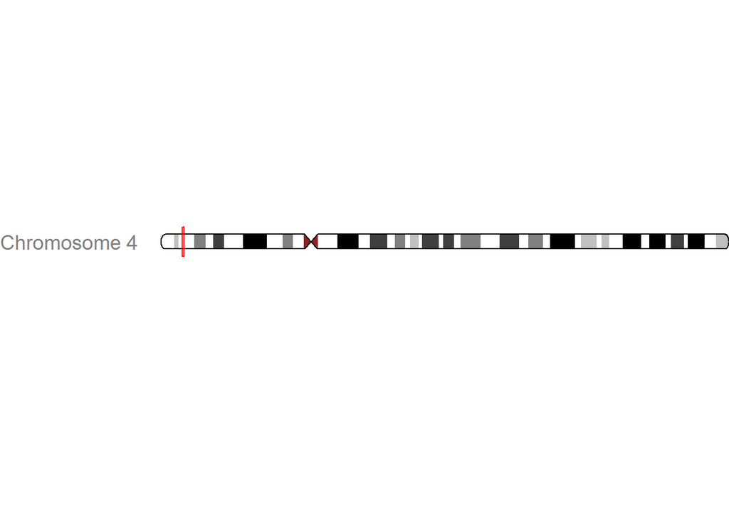

```r
grid.newpage()
pushViewport(viewport(height=0.07, y=0.5, just="bottom"))
plotTracks(chrTr, from = start ,to = end, panel.only = TRUE, add=TRUE)
popViewport()
```

```r
## plot other figures
par(no.readonly=TRUE)
```

[output not shown]

[output not shown]

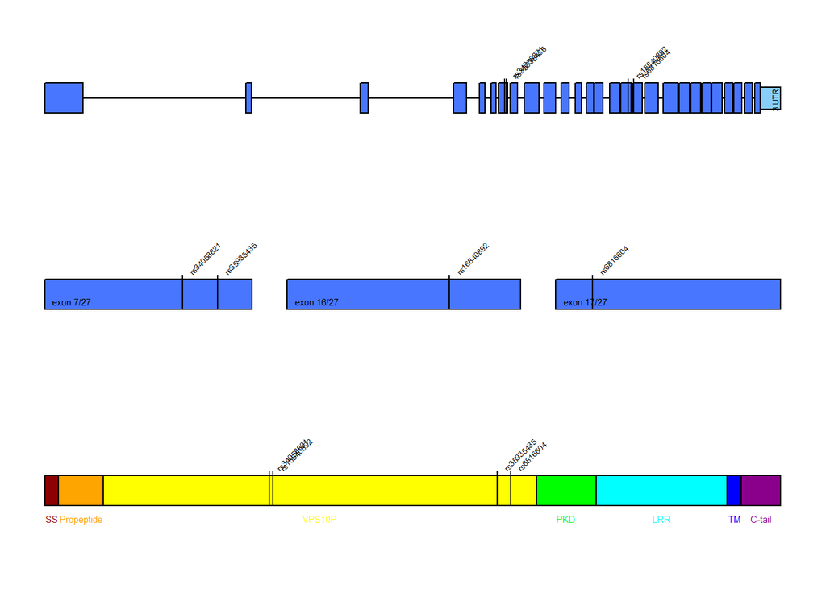

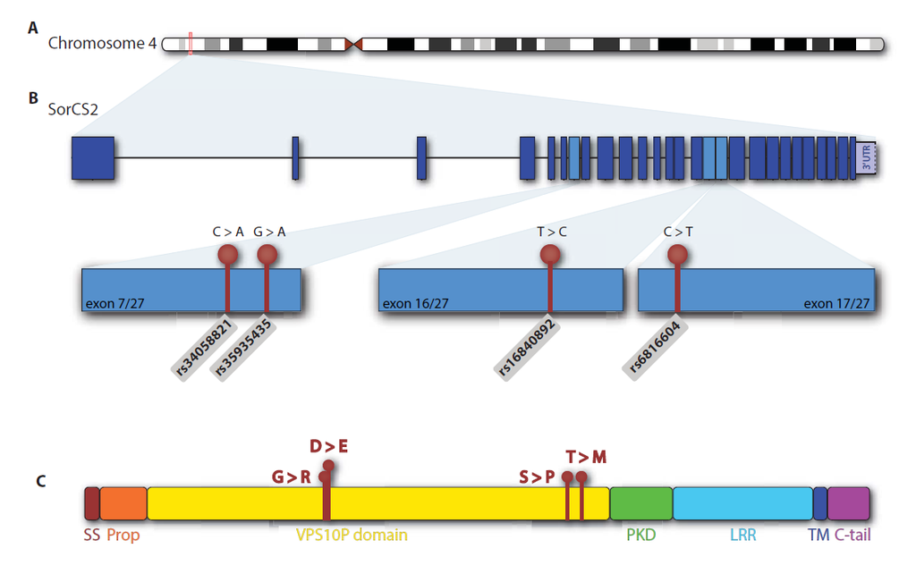

```r
grid.newpage()
#pushViewport(viewport(width=1, height=1))

par(mfrow=c(3,1),mfg=c(3,1),mar=c(3,1,3,1))


# initiate plot
plot(c(0, s2end), c(-250, 250), type= "n", xaxt='n', ylab="",xlab="",yaxt='n',frame.plot=FALSE)

# plot exons and introns
for (i in 1:(length(s2exlength)-1)) {
  rect(s2exstart[i], -wd, s2instart[i]-1, wd, col="royalblue1", border="black") #exons
  rect(s2instart[i], -0.2, s2exstart[i+1]-1, 0.2, col="grey", border="black") #introns
}
rect(s2exstart[length(s2exlength)], -wd, s2instart[length(s2exlength)], wd, col="royalblue1", border="black") #last exon
rect(s2instart[length(s2exlength)],-0.75*wd, s2end, 0.7*wd, col="lightskyblue", border="black" ) #3'UTR

# plot SNPs
for (i in 1:(length(snps))) {
  rect(s2exstart[snpexon[i]]+snpexpos[i]-0.1, -wd, s2exstart[snpexon[i]]+snpexpos[i]+0.1, wd+20, col="black", border="black")
}
# plot SNP names
for (i in 1:(length(snps))) {
  text(s2exstart[snpexon[i]]+snpexpos[i],wd+30, labels = sorcs2$id[i], cex=0.9*cex, srt = 45, pos =4)
}
text(s2instart[length(s2inlength)],-wd+10, labels = "3'UTR", cex=0.9*cex, srt = 90, pos =4, offset = 1) #plot 3'UTR


# initiate plot
plot(c(s2length[1], s2length[length(s2length)]), c(-250, 250), xaxt='n', ylab="", xlab="", yaxt='n', type= "n",frame.plot=FALSE)

# plot exons
for (i in 1:length(snpexes)) {
  rect(s2length[i], -wd, s2length[i] + s2exlength[snpexes[i]], wd, col="royalblue1", border="black") #exons
}

# plot SNPs
for (i in 1:(length(snps))) {
  rect(s2length[snpexes==snpexon[i]]+snpexpos[i]-0.01, -wd, s2length[snpexes==snpexon[i]]+snpexpos[i]+0.01, wd + 20, col="black", border="black") }
# plot SNP names
for (i in 1:(length(snps))) {
  text(s2length[snpexes==snpexon[i]]+snpexpos[i],wd +30, labels = sorcs2$id[i], cex=0.9*cex, srt = 45, pos =4) }
# plot exon names
exonnum <- paste("exon ", snpexes,"/",length(s2exlength),sep="")
for (i in 1:(length(snpexes))) {
  text(s2length[i],-0.5*wd, labels = exonnum[i], cex=1*cex, pos =4) }


# initiate plot
plot(c(0, s2protlength), c(-250, 250), type= "n", xaxt='n', ylab="",xlab="",yaxt='n',frame.plot=FALSE)

# plot domains in different colors
rect(0, -wd, s2domlength[i], wd, col=domcol[1], border="black")
for (i in 2:length(s2dom))
  rect(s2domend[i-1], -wd, s2domend[i], wd, col=domcol[i], border="black")

# plot SNPs
for (i in 1:(length(snps))) {
  rect(3*protsnps[i]-0.1, -wd, 3*protsnps[i]+0.1, wd + 20, col="black", border="black")
}
# plot domain names
text(s2domend[1]/2,- wd - 10, labels = names(s2domlength[1]), cex=1*cex, pos=1, col=domcol[1])
for (i in 2:(length(s2domend))) {
  text(s2domend[i-1]+(s2domend[i]-s2domend[i-1])/2, -wd - 10, labels = names(s2domlength[i]), cex=1*cex, pos=1, col=domcol[i])
}
# plot SNP names
for (i in 1:(length(snps))) {
  text(3*protsnps[i],wd + 30, labels = sorcs2$id[i], cex=0.9*cex, srt = 45, pos =4) }
```

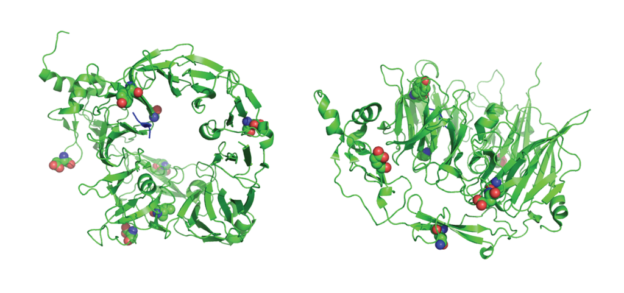

*Figure 2* | SorCS2 protein model. Position of SNPs of interest indicated as spheres.

### Joseph’s Content

ADSP data was processed using the Genome GPS pipeline by the Bioinformatics Core in Rochestor. After variant calling (using ‘GenotypeGVCFs’ in the GATK pipeline), variants were annotated using BioR.  
Variants from genes of interest (here, SORCS2) were identified and processed using Perl scripts to generate files for downstream analysis.

```r
system("perl generate_flat_file_SG.pl ADSP ADSP_sample_sex_age_AD_APOE.txt SORCS2_variants.txt 1000 SORCS2_ff.txt SORCS2_allele_counts.txt")

#Sex : 0: Male, 1: Female
#Case/Control: 0: Control, 1: AD, 2: Probable AD
#Call: 11/12/22
#Genotype: 0/0, 0/1, 1/1,  [./., ./0, ./1, 0/., 1/. encoded as NA]

#Importing Flat File
SORCS2_FF <- read.table("SORCS2_ff.txt",header = TRUE, check.names = FALSE)
head(SORCS2_FF)

#Importing allele counts for each variant
SORCS2_variants <- read.table("SORCS2_allele_counts.txt", header = TRUE, check.names = FALSE)
head(SORCS2_variants)
```

[output not shown]